# Servicios Ubicuos Adaptativos ExtraSensory Project

José Manuel Bernabé Murcia

```r
library(tidyverse)
library(lubridate)
library(reshape2)
library(dplyr)
library(corrplot)
library(ggplot2)
library(anytime)
library(scales)
library(pvclust)
library(caret)
library(cluster)
library(factoextra)
library(mlbench)
library(moments)
library(gridExtra)
library(rpart)
library(partykit)
library(e1071)
library(randomForest)
library(rattle)
```

# Introduction Dataset ExtraSensory

The dataset collects a set of behaviors on 60 subjects and recording the values of the sensors to relate it to said behavior. The sensors will be described later.

The objective of this practice is that with these data we have to be able to use machine learning tools to help us identify the behaviors.

# Reading the dataset

Reading Data, There are 60 ‘csv.gz’ files, one for each participant (user, subject) in the data collection. We ordered it by timestamp

```r
listaTemp = list.files('data/', pattern = '.*csv')
data <- (read.csv(file=paste("data/",listaTemp[1], sep=""), header=TRUE, sep=","))
id <- str_extract(listaTemp[1],"^[A-Z|0-9-]*")
idColumna <-  data.frame(c(rep(id,nrow(data))))
idUser <- idColumna
colnames(idUser)[1] <- "idUser"



for(i in 2:length(listaTemp)){
  temp <- (read.csv(file=paste("data/",listaTemp[i], sep=""), header=TRUE, sep=","))
  id <- str_extract(listaTemp[i],"^[A-Z|0-9-]*")
  idColumna <- data.frame(c(rep(id,nrow(temp))))
  colnames(idColumna)[1] <- "idUser"
  idUser <- rbind(idUser, idColumna)
  data <- rbind(data, temp)
}
```

# Pre-Analysis

Before starting the analysis we will try to eliminate or replace the null values. The discrete values will be replaced by mode and continuous values by the average.

1. First we will analyze if we have a whole column of NA’s, in which case we will eliminate it.
2. The column that exceeded 70% with null values will be eliminated.
3. The remaining values will be replaced.

```r
#Funcion que calcula la moda
getmode <- function(v) {
   uniqv <- unique(v)
   uniqv[which.max(tabulate(match(v, uniqv)))]
}

columnas_eliminar <- c()
data <- data[,colSums(is.na(data))<nrow(data)]
j <- 0
for(i in 1:ncol(data)){
  if(sum(is.na(data[,i])) > 0){
    if(((sum(is.na(data[,i]))*100)/(sum(!is.na(data[,i]))+sum(is.na(data[,i])))) >= 70 ){
         cat("Columnas que se eliminarán por superan el umbral de NA's: ",colnames(data[i]),"(>=70% NA's)\n")
         columnas_eliminar[j] <- i;
         j<-j+1;
    }
  }
}
```

```
## Columnas que se eliminarán por superan el umbral de NA's:  location.min_speed (>=70% NA's)
## Columnas que se eliminarán por superan el umbral de NA's:  location.max_speed (>=70% NA's)
## Columnas que se eliminarán por superan el umbral de NA's:  lf_measurements.pressure (>=70% NA's)
## Columnas que se eliminarán por superan el umbral de NA's:  lf_measurements.relative_humidity (>=70% NA's)
## Columnas que se eliminarán por superan el umbral de NA's:  lf_measurements.temperature_ambient (>=70% NA's)
## Columnas que se eliminarán por superan el umbral de NA's:  label.LAB_WORK (>=70% NA's)
## Columnas que se eliminarán por superan el umbral de NA's:  label.IN_CLASS (>=70% NA's)
## Columnas que se eliminarán por superan el umbral de NA's:  label.STROLLING (>=70% NA's)
## Columnas que se eliminarán por superan el umbral de NA's:  label.DRINKING__ALCOHOL_ (>=70% NA's)
## Columnas que se eliminarán por superan el umbral de NA's:  label.DOING_LAUNDRY (>=70% NA's)
## Columnas que se eliminarán por superan el umbral de NA's:  label.AT_A_PARTY (>=70% NA's)
## Columnas que se eliminarán por superan el umbral de NA's:  label.AT_A_BAR (>=70% NA's)
## Columnas que se eliminarán por superan el umbral de NA's:  label.LOC_beach (>=70% NA's)
## Columnas que se eliminarán por superan el umbral de NA's:  label.SINGING (>=70% NA's)
## Columnas que se eliminarán por superan el umbral de NA's:  label.AT_THE_GYM (>=70% NA's)
## Columnas que se eliminarán por superan el umbral de NA's:  label.STAIRS_._GOING_UP (>=70% NA's)
## Columnas que se eliminarán por superan el umbral de NA's:  label.STAIRS_._GOING_DOWN (>=70% NA's)
## Columnas que se eliminarán por superan el umbral de NA's:  label.ELEVATOR (>=70% NA's)
## Columnas que se eliminarán por superan el umbral de NA's:  label.PHONE_IN_BAG (>=70% NA's)
## Columnas que se eliminarán por superan el umbral de NA's:  label.WITH_CO.WORKERS (>=70% NA's)
```

```r
data <- select(data, -columnas_eliminar)


for(i in 1:ncol(data)){
  if(startsWith(as.character(colnames(data[i])), "label")){
    if((getmode(data[,i])) == 'NaN') data[is.na(data[,i]), i] <- 0
    else data[is.na(data[,i]), i] <- getmode(data[,i])

  }
  else{
     data[is.na(data[,i]), i] <- mean(data[,i], na.rm = TRUE)
  }
}

data_individuos <- cbind(data, idUser)
data <- arrange(data, data$timestamp)
```

## Coding the output

we will only treat six context labels that will be the main behaviors, therefore, we will generate a column which will contain for each row the name of the label that corresponds to the behavior, and an additional one with the unknown value

```r
labels <- select(data, (c('label.LYING_DOWN', 'label.SITTING', 'label.OR_standing', 'label.FIX_walking', 'label.FIX_running', 'label.BICYCLING')))
z <- 1

cod.salida <- c()
for(i in 1:nrow(labels)){
  etiqueta_seguida <- 0
  for(j in 1:ncol(labels)){
    if (labels[i,j] == 1){
      if(etiqueta_seguida == 1){
        cod.salida[z] <- paste(cod.salida[z] , colnames(labels[j]), sep='+');
      }
      else{
        cod.salida[z] <-colnames(labels[j]);
      }

      etiqueta_seguida <- 1

    }


  }
  if(etiqueta_seguida == 0) cod.salida[z] <- "NS/NC"
  z<-z+1;
}
```

# Characterize data features on the sensors available

## Which sensors are there and what types of data them produce

| Sensor | Measurements |
| --- | --- |
| Accelerometer | 3-Axis (40Hz) |
| Gyroscope | 3-Axis (40Hz) |
| Magnetometer | 3-Axis (40Hz) |
| Watch Accelerometer | 3-Axis (25Hz) |
| Watch Compass | Heading angle (var) |
| Location | Long-lat-alt (var) |
| Location precomputed | Location Variability (1pe) |
| Audio | 13MFCC (46ms frames) |
| Audio power | 1pe |
| Phone State | 1pe |
| Low frequency sensors | 1pe |

“1pe”" means sampled once per example. “var” means variable sampling rate — gathering updates whenever the value changes.

Now I will visualize them directly from the dataset

```r
sensors <- select(data, matches("(^raw_acc|^proc_gyro|^raw_magnet|^watch_acceleration|^watch_heading|^location|^location_quick_features|^audio_naive|^audio_properties|^discrete|^lf_measurements)"))

nameSensor <- "empty"
typeSensor <- "Na"

for(i in 1:length(sensors)){
  if(nameSensor == unlist(strsplit(names(sensors[i]), ".", fixed = TRUE))[[1]]){
    next;
  }

  nameSensor <- unlist(strsplit(names(sensors[i]), ".", fixed = TRUE))[[1]]
  cat(sprintf("%-40s %s\n",names(sensors[i]),typeof(sensors[[i]])))
}
```

```
## raw_acc.magnitude_stats.mean             double
## proc_gyro.magnitude_stats.mean           double
## raw_magnet.magnitude_stats.mean          double
## watch_acceleration.magnitude_stats.mean  double
## watch_heading.mean_cos                   double
## location.num_valid_updates               double
## location_quick_features.std_lat          double
## audio_naive.mfcc0.mean                   double
## audio_properties.max_abs_value           double
## discrete.app_state.is_active             double
## lf_measurements.light                    double
## discrete.time_of_day.between0and6        double
```

All the data they produce are numeric, as we can see. Further, for each sensor we have statistics of the magnitude signal such as: mean, standar deviation, third moment, fourth moment, 25 percentile, 50 percentile, 75 percentile, value entropy and time entropy, but I have grouped them so as not to make the document very long.

## Are they correlated?

Having so many variables, we will use a correlation matrix between two variables only, since if we use all the varibles it would be practically impossible to see anything. In this case I have selected all the variables of the gyroscope and the accelerometer.

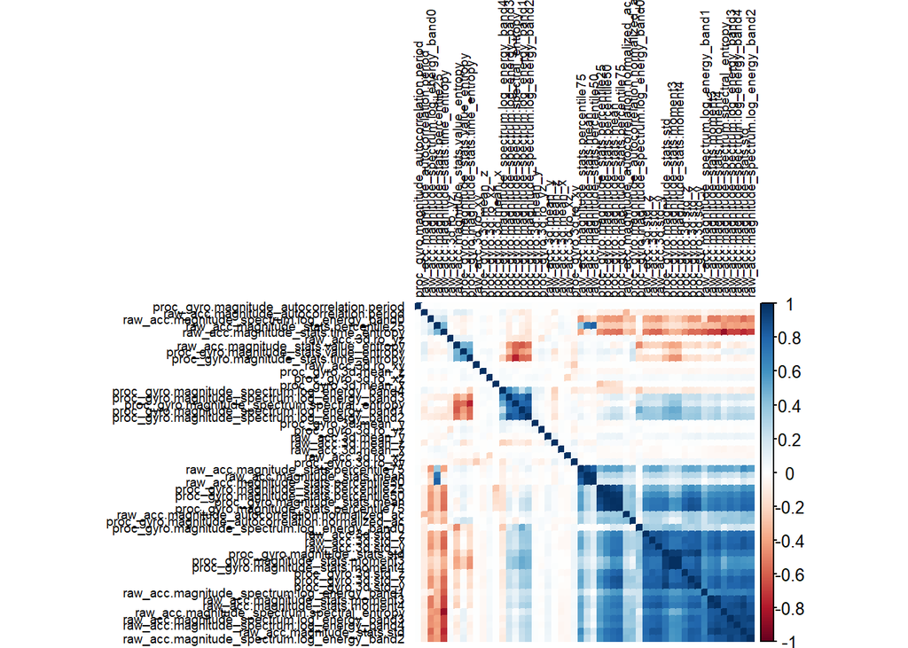

```r
sensors <- select(data, matches("(^proc_gyro|^raw_acc)"))
sensors[is.na(sensors)] <- 0
oc_cor <- cor(sensors)
oc_cor[is.na(oc_cor)]  <- 0
corrplot(oc_cor, method="color",type = "full", order = "hclust", tl.col = "black", tl.cex = 0.6 )
```

As you can see the sensors (accelerometer and gyroscope), they have both positive and negative correlations between attributes. This makes us think that by applying some feature selection technique we could obtain the most representative variables.

Since we have correlations, I will execute the algorithm of simple elimination of correlation variables by threshold, the objective is to remain with fewer variables since with many variables an overfit can be produced. In order to execute it, the algorithm must not receive constant variables (standard deviation 0), nor columns with null values, which we have already discussed.

```r
features <- select(data, -starts_with('label'))
features <- select(features, -starts_with('timestamp'))
colnum_features <- ncol(features)
#Eliminamos las columnas donde la desviación estandar sea cero.
features<- Filter(var, features)
cat("Teniamos un total de variables antes de eliminar: ",colnum_features, ". Ahora tenemos un total de: ",ncol(features))
```

```
## Teniamos un total de variables antes de eliminar:  221 . Ahora tenemos un total de:  217
```

```r
remove = findCorrelation(cor(features), cutoff=0.9)
cat("Variables to remove are",colnames(features[remove]),"\n", "\nTenemos un total de variables a eliminar de: ",length(remove)," varibles.\n")
```

```
## Variables to remove are raw_acc.magnitude_stats.moment4 raw_acc.magnitude_stats.percentile75 raw_acc.magnitude_spectrum.log_energy_band3 raw_acc.magnitude_spectrum.log_energy_band4 proc_gyro.magnitude_stats.moment4 proc_gyro.magnitude_stats.percentile50 proc_gyro.magnitude_stats.percentile75 proc…
##
## Tenemos un total de variables a eliminar de:  46  varibles.
```

```r
features <- select(features, -c(remove))
cat("Teniamos un total de variables antes de eliminar: ",colnum_features,"Ahora tenemos un total de: ",ncol(features)," variables.")
```

```
## Teniamos un total de variables antes de eliminar:  221 Ahora tenemos un total de:  171  variables.
```

```r
#corrplot(cor(features), type = "upper", tl.pos = "td", method = "circle", tl.cex = 0.5, tl.col = 'black')
```

Later we will make use of algorithms to stay the most “important” predictors and thus be able to reduce it even more.

## Distribution of data from sensors

Now we will see how the data are distributed, to be able to know what type of distribution our data follow. For this I use the functions: skewness and kurtosis. From the library moments. I will show only the first 10 data, the other half I omit to not make the document too long.

```r
for(i in 1:10){

  cat("Skewness y kurtosis:",skewness(features[,i]),"/",kurtosis(features[,i]),colnames(features[,i]),"\n")



}
```

```
## Skewness y kurtosis: 4.445611 / 28.22574
## Skewness y kurtosis: -5.217633 / 73.69006
## Skewness y kurtosis: -5.641063 / 106.9005
## Skewness y kurtosis: -1.078718 / 0.2237924
## Skewness y kurtosis: -17.18319 / 577.223
## Skewness y kurtosis: 10.02596 / 496.8079
## Skewness y kurtosis: 6.268092 / 54.01953
## Skewness y kurtosis: 3.296933 / 10.43648
## Skewness y kurtosis: 6.455742 / 62.61486
## Skewness y kurtosis: 1.631504 / 2.168096
```

If the skewness is zero it means that the data follow a normal distribution, however, if we have a positive skewness greater than zero, the “tail” of the distribution points to the right. The kurtosis will tell us how “weeping” the data is, that is, if it is positive and the higher the value of the kurtosis the more weights are the data. For example, we can see this situation in the variable raw_acc.magnitude_stats.moment3 Plotting we will see it.

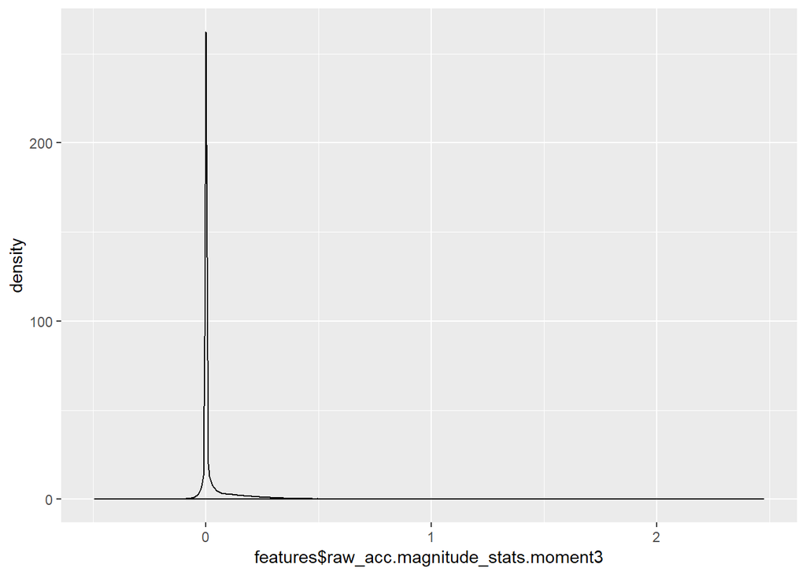

```r
  ggplot(features, aes(x=features$raw_acc.magnitude_stats.moment3)) + geom_density()
```

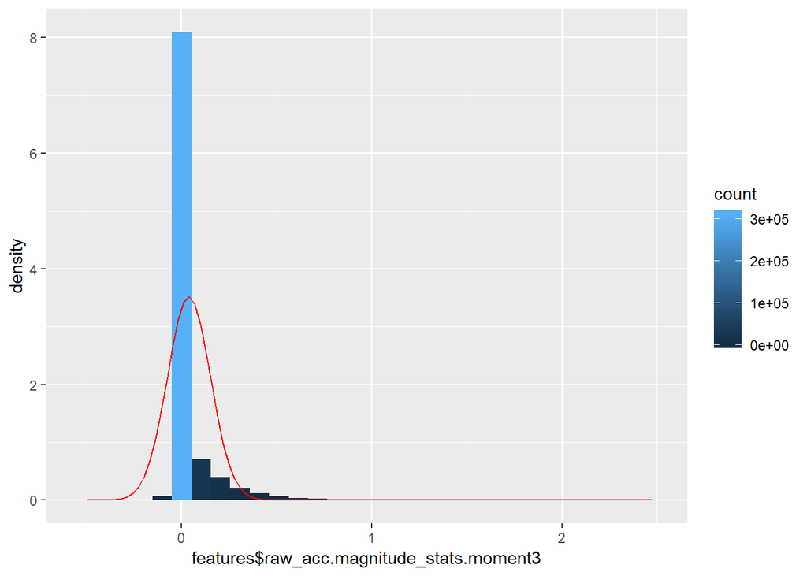

```r
  ggplot(features, aes(x=features$raw_acc.magnitude_stats.moment3)) +
  geom_histogram(aes(y=..density.., fill=..count..))+
  stat_function(fun=dnorm,color="red",args=list(mean=mean(features$raw_acc.magnitude_stats.moment3),sd=sd(features$raw_acc.magnitude_stats.moment3)))
```

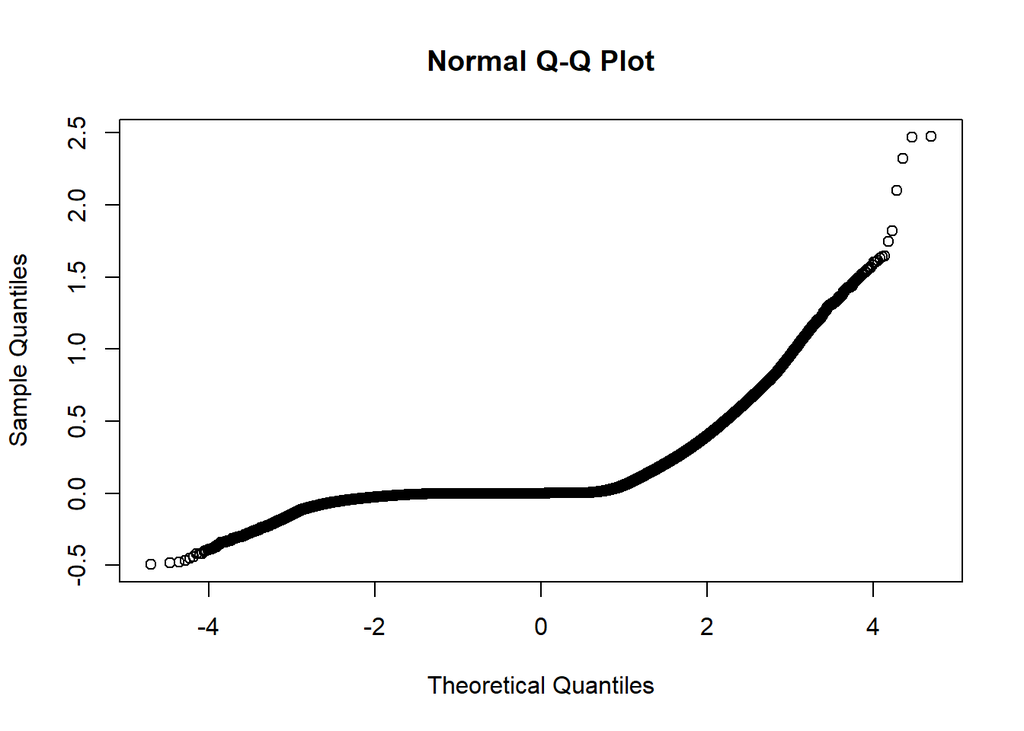

```r
qqnorm(features$raw_acc.magnitude_stats.moment3)
```

Our data does not follow a normal distribution. Therefore, our data needs to be transformed, in this case scaled to be able to normalize them. Why? Because we have to put them on a common scale, since this will improve the understanding of their distribution and be able to compare them more easily avoiding the distortion of scale difference as well as the fact that in this way problems with the algorithms are avoided of adjustment of models that do not possess the property of invariance to scaling, for example, algorithms based on descent gradient (such as neural networks that use backpropagation).

# Subjects

The ExtraSensory dataset contains data from 60 users (34 subjects were female and 26 were male). The users would use their own phone, and possibly additional convenient devices, like watches (56 out of the 60 agreed to wear the watch). For the purpose of large-scale data collection the creators of extrasensory developed a mobile application for both iphone and android and for smartwatch (Pebble). The app was used to collect both sensor measurement and context labels. Every minute the app records a 20sec window of sensor measurements from the phone and watch.

We can see the different context labels and the time that we have.

```r
labels <- select(data, starts_with('label'))
timeLabel <- select(labels, -label_source)
timeLabel <- apply(timeLabel,2,function(x){sum(as.numeric(x), na.rm = TRUE)})
timeLabel <- sort(timeLabel, decreasing = TRUE)




for (i in 1:length(timeLabel)){
  cat(sprintf("%-40s %d minutes \n",names(timeLabel[i]),unname(timeLabel[i])))

}
```

```
## label.OR_indoors                         365232 minutes
## label.LOC_home                           152892 minutes
## label.SITTING                            136356 minutes
## label.PHONE_ON_TABLE                     115037 minutes
## label.LYING_DOWN                         104210 minutes
## label.SLEEPING                           83055 minutes
## label.AT_SCHOOL                          42331 minutes
## label.COMPUTER_WORK                      38081 minutes
## label.OR_standing                        37782 minutes
## label.TALKING                            36293 minutes
## label.LOC_main_workplace                 33944 minutes
## label.WITH_FRIENDS                       24737 minutes
## label.PHONE_IN_POCKET                    23401 minutes
## label.FIX_walking                        22136 minutes
## label.SURFING_THE_INTERNET               19416 minutes
## label.EATING                             16594 minutes
## label.PHONE_IN_HAND                      14573 minutes
## label.WATCHING_TV                        13311 minutes
## label.OR_outside                         12114 minutes
## label.OR_exercise                        8081 minutes
## label.DRIVE_._I_M_THE_DRIVER             7975 minutes
## label.IN_A_CAR                           6083 minutes
## label.IN_A_MEETING                       5153 minutes
## label.BICYCLING                          5020 minutes
## label.COOKING                            4029 minutes
## label.CLEANING                           3806 minutes
## label.GROOMING                           3064 minutes
## label.TOILET                             2655 minutes
## label.DRIVE_._I_M_A_PASSENGER            2526 minutes
## label.DRESSING                           2233 minutes
## label.FIX_restaurant                     2098 minutes
## label.BATHING_._SHOWER                   2087 minutes
## label.SHOPPING                           1841 minutes
## label.ON_A_BUS                           1794 minutes
## label.WASHING_DISHES                     1228 minutes
## label.FIX_running                        1090 minutes
```

We can see the test times we have in our whole set.

## Report types

The users could report of two types:

1. Main activity. Labels describing movement or posture of the user.
2. Secondary activity. Labels describing more specific context in different aspects: sports (e.g. playing basketball, at the gym), transportation (e.g. drive - I’m the driver, on the bus), basic needs (e.g. sleeping, eating, toilet), company (e.g. with family, with co-workers), location (e.g. at home, at work, outside) etc. Multiple secondary labels can be applied to an example.

## Try search patterns and relationships

In this picture we can see on the X axis we have the hours and on the Y axis we have the context labels. In this way it is already possible to see routines and patterns, For example, on May 25 and 26.

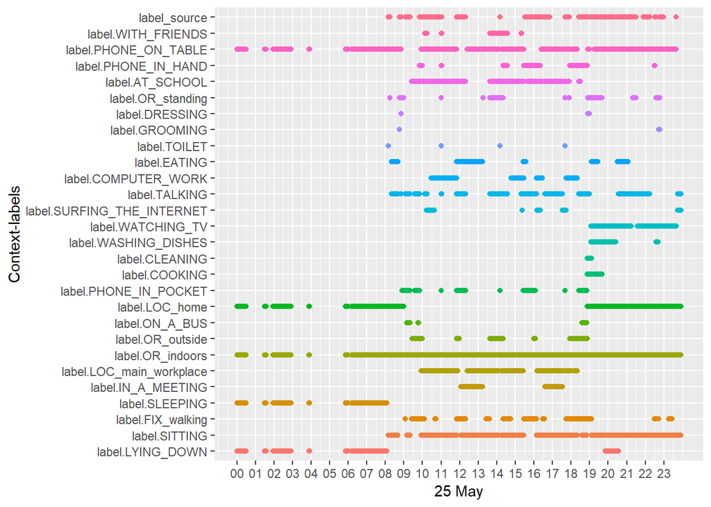

```r
labels_day <- select(data, starts_with('label'))
labels_day <- cbind(labels_day, data$timestamp)
labels_day <- melt(labels_day, c('data$timestamp'))
colnames(labels_day)[1] <- 'timestamp'
fecha <- anytime(labels_day$timestamp, tz="PST8PDT")
fecha <- format(as.POSIXct(fecha, "%Y-%m-%d %H:%M:%S", tz = ""), format = "%Y-%m-%d %H:%M")
labels_day <- cbind(labels_day, fecha)
labels_day <- filter(labels_day, format(as.POSIXct(labels_day$fecha, "%Y-%m-%d %H:%M", tz = ""), format = "%Y-%m-%d") == "2016-05-25")
labels_day <- filter(labels_day, value == 1)



ggplot(data = labels_day, aes(x = as.POSIXct(labels_day$fecha), y = variable, color=variable) )+
  geom_point()+
  theme(legend.position = "none")+
  scale_x_datetime(
    breaks = seq(min(as.POSIXct(labels_day$fecha)),
                 max(as.POSIXct(labels_day$fecha)), "1 hours"),
     labels = date_format("%H", tz = "CET")
    )+
  labs(x  = "25 May", y = "Context-labels")
```

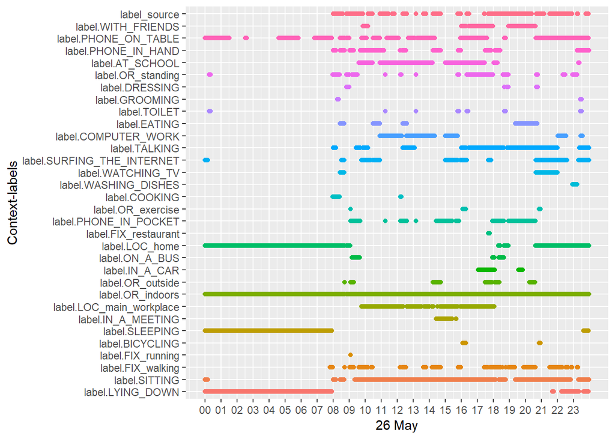

```r
labels_day <- select(data, starts_with('label'))
labels_day <- cbind(labels_day, data$timestamp)
labels_day <- melt(labels_day, c('data$timestamp'))
colnames(labels_day)[1] <- 'timestamp'
fecha <- anytime(labels_day$timestamp, tz="PST8PDT")
fecha <- format(as.POSIXct(fecha, "%Y-%m-%d %H:%M:%S", tz = ""), format = "%Y-%m-%d %H:%M")
labels_day <- cbind(labels_day, fecha)
labels_day <- filter(labels_day, format(as.POSIXct(labels_day$fecha, "%Y-%m-%d %H:%M", tz = ""), format = "%Y-%m-%d") == "2016-05-26")
labels_day <- filter(labels_day, value == 1)
horas_dia_26 <- format(as.POSIXct(labels_day$fecha, "%H:%M", tz = ""), format = "%H")



ggplot(data = labels_day, aes(x = as.POSIXct(labels_day$fecha), y = variable, color=variable) )+
  geom_point()+
  theme(legend.position = "none")+
  scale_x_datetime(
    breaks = seq(min(as.POSIXct(labels_day$fecha)),
                 max(as.POSIXct(labels_day$fecha)), "1 hours"),
     labels = date_format("%H", tz = "CET")
    )+
  labs(x  = "26 May", y = "Context-labels")
```

We can intuit from the images that there is a relationship between 00:00 and 08:00 with the context labels: sleeping and lying down. But it’s hard to appreciate with all the individuals together.

## Correlation matrix between the context labels

With the correlation matrix it is easier to see the correlations between the labels.

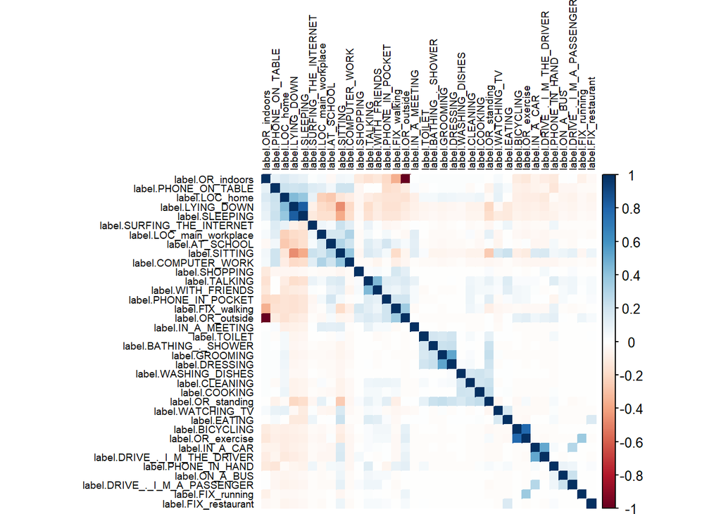

```r
oc <- select(data, starts_with('label'))
oc <- select(oc, -starts_with('label_source'))
oc[is.na(oc)] <- 0
oc <- oc[, colSums(oc) > 1]
oc_cor <- cor(oc)
oc_cor[is.na(oc_cor)]  <- 0
corrplot(oc_cor, method="color",type = "full", order = "hclust", tl.col = "black", tl.cex = 0.6 )
```

We can see groupings that we have detected before visualizing the data.

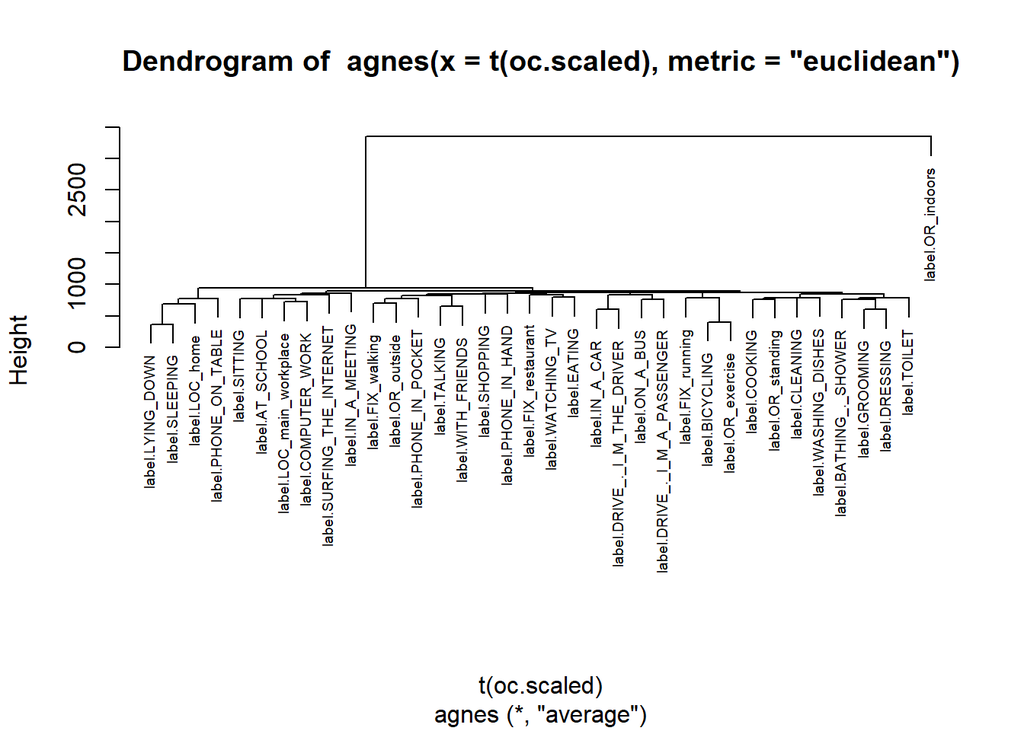

```r
set.seed(123)
oc <- select(data, starts_with('label'))
oc <- select(oc, -starts_with('label_source'))
oc[is.na(oc)] <- 0
oc <- oc[, colSums(oc) > 1]
#oc <- t(oc)
oc.pre <- preProcess(oc,method="scale")
oc.scaled <- predict(oc.pre, oc)
oc.diana <- agnes(t(oc.scaled), metric="euclidean")
pltree(oc.diana,cex=.6)
```

here I set K equal to 8, to point out the clusters (It’s a random value)

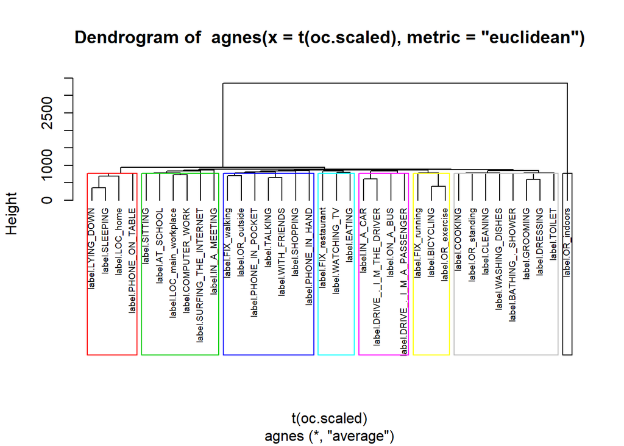

```r
set.seed(123)
oc <- select(data, starts_with('label'))
oc <- select(oc, -starts_with('label_source'))
oc[is.na(oc)] <- 0
oc <- oc[, colSums(oc) > 1] #Evito columnas sin más de un ejemplo
#oc <- t(oc)
oc.pre <- preProcess(oc,method="scale")
oc.scaled <- predict(oc.pre, oc)
oc.agnes <- agnes(t(oc.scaled), metric="euclidean")
pltree(oc.agnes, hang=-1, cex = 0.6)
rect.hclust(oc.agnes, k = 8, border = 2:10)
```

Now we can visualize some groups that we have found using clustering techniques or fixing ourselves in the correlation matrix, since they make sense. For example, when you are at home lying down you are sleeping.

## Table subjects examples

```r
tabla_registros <- data_individuos %>%
  group_by(idUser) %>%
  summarise(LYING_DOWN = sum(label.LYING_DOWN, na.rm = TRUE), SITTING= sum(label.SITTING, na.rm = TRUE), OR_Standing= sum(label.OR_standing, na.rm = TRUE), FIX_walking= sum(label.FIX_walking, na.rm = TRUE), FIX_running= sum(label.FIX_running, na.rm = TRUE), BICYCLING= sum(label.BICYCLING, na.rm = TRUE))

 tabla_registros <- arrange(tabla_registros, tabla_registros$LYING_DOWN, tabla_registros$SITTING,tabla_registros$OR_Standing, tabla_registros$FIX_walking, tabla_registros$FIX_running, tabla_registros$BICYCLING)

 tabla_registros
```

| idUser | LYING_DOWN | SITTING | OR_Standing | FIX_walking | FIX_running | BICYCLING |
| --- | --- | --- | --- | --- | --- | --- |
| 7D9BB102-A612-4E2A-8E22-3159752F55D8 | 0 | 621 | 2 | 61 | 0 | 0 |
| 0BFC35E2-4817-4865-BFA7-764742302A2D | 0 | 1301 | 370 | 375 | 35 | 106 |
| ECECC2AB-D32F-4F90-B74C-E12A1C69BBE2 | 25 | 956 | 101 | 156 | 0 | 0 |
| 24E40C4C-A349-4F9F-93AB-01D00FB994AF | 102 | 1728 | 978 | 363 | 0 | 59 |
| 797D145F-3858-4A7F-A7C2-A4EB721E133C | 214 | 1766 | 177 | 397 | 283 | 2 |
| 59818CD2-24D7-4D32-B133-24C2FE3801E5 | 233 | 1561 | 399 | 236 | 9 | 369 |
| BEF6C611-50DA-4971-A040-87FB979F3FC1 | 339 | 1265 | 114 | 117 | 0 | 0 |
| A7599A50-24AE-46A6-8EA6-2576F1011D81 | 352 | 2420 | 501 | 507 | 0 | 0 |
| CF722AA9-2533-4E51-9FEB-9EAC84EE9AAC | 469 | 2523 | 122 | 402 | 14 | 0 |
| E65577C1-8D5D-4F70-AF23-B3ADB9D3DBA3 | 497 | 757 | 357 | 147 | 0 | 268 |

[output cut: 50 more lines]

Here we have the subject with your examples. We can think in remove some subject that have few examples and can introduce some noise, but we can only know if we will study it more in depth.

# Making our model and training it

## Making timestamp a cyclic variable for machine learning

Before starting with the transformation of the model, I will create two variables to represent the time cycle that the variable timestamp has. Once created, you will not have to use the timestamp, therefore, the elimination.

The objective is to convert the time stamp variable that is cyclical in such a way that the machine learning algorithm is also known to be cyclical

https://ianlondon.github.io/blog/encoding-cyclical-features-24hour-time

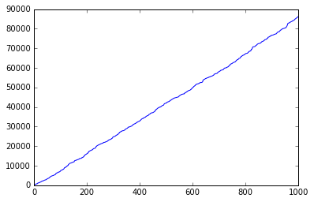

Notice that the distance between a point as 5 minutes before and 5 minutes after the split is very large. This is undesirable: we want our machine learning model to see that 23:55 and 00:05 are 10 minutes apart, but as it stands, those times will appear to be 23 hours and 50 minutes apart!

The x position swings back and forth out of sink with the y position. For a 24-hour clock you can accomplish this with x=sin(2pi*hour/24),y=cos(2pi*hour/24).

You need both variables or the proper movement through time is lost. This is due to the fact that the derivative of either sin or cos changes in time where as the (x,y) position varies smoothly as it travels around the unit circle.

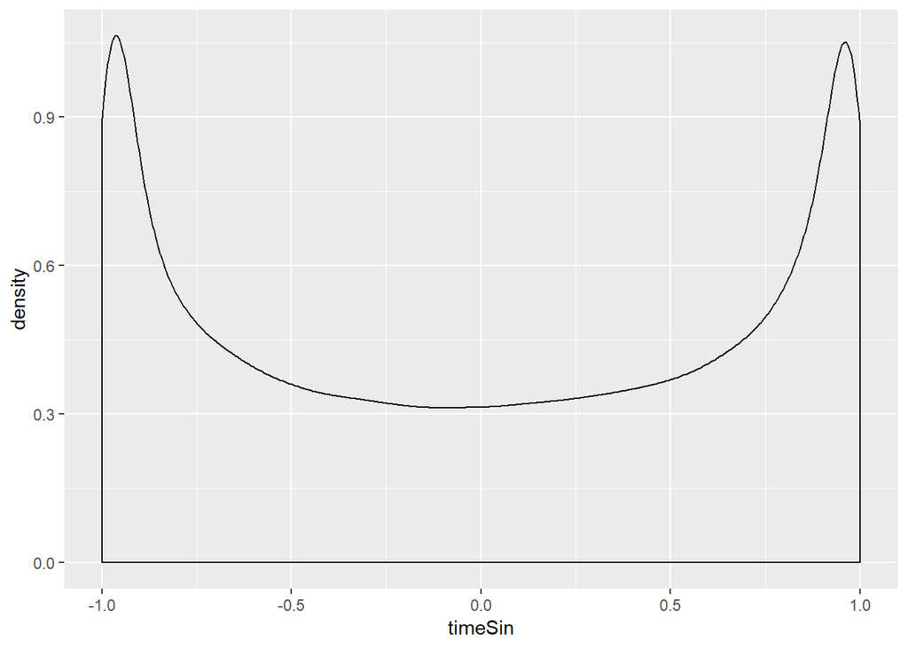

```r
set.seed(123)

seconds_in_day = 24*60*60

time1 <- as.data.frame(sin(2*pi*data["timestamp"]/seconds_in_day))
time2 <- as.data.frame(cos(2*pi*data["timestamp"]/seconds_in_day))

colnames(time1) <- "timeSin"
colnames(time2) <- "timeCos"

tiempo_ciclico <- cbind(time1, time2)


data<-cbind(tiempo_ciclico, data)

ggplot(data, aes(timeSin))+geom_density()
```

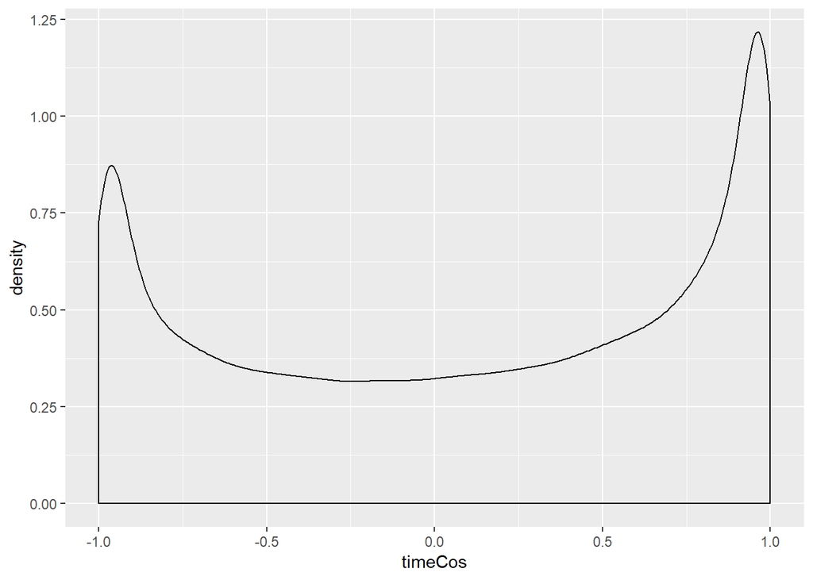

```r
ggplot(data, aes(timeCos))+geom_density()
```

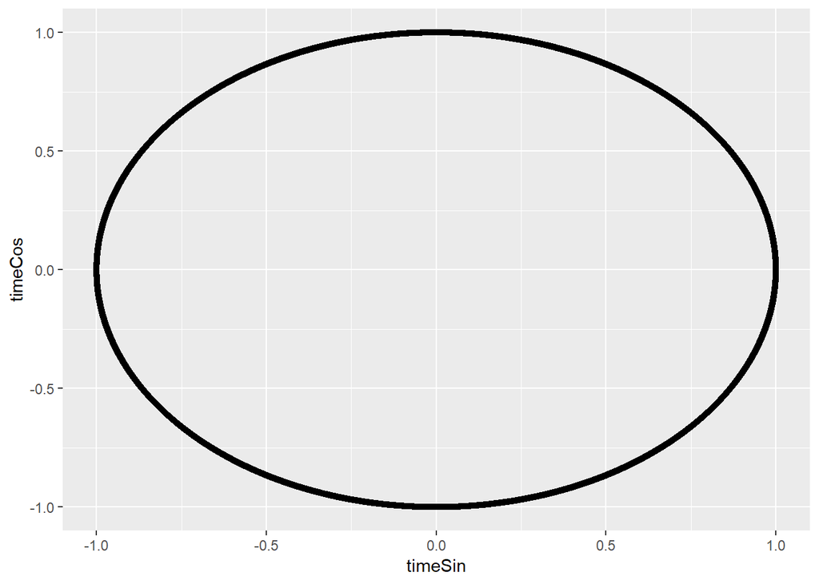

```r
ggplot(data, aes(timeSin, timeCos))+geom_point()
```

```r
horas <- anytime(data$timestamp, tz="PST8PDT")
horas <- format(as.POSIXct(horas, "%Y-%m-%d %H:%M:%S", tz = ""), format = "%Y-%m-%d %H:%M")
horas <- format(as.POSIXct(horas, "%Y-%m-%d %H:%M", tz = ""), format = "%H")
```

## Normalizing the features.

For the algorithms that we are going to use as rpart and randomForest, these require that the data be normalized, therefore, we use preprocess and normalize our data.

```r
set.seed(123)
timeSin <- select(data, starts_with('timeSin'))
timeCos <- select(data, starts_with('timeCos'))
labels <- select(labels, -starts_with("label_source"))
#La parte de los features ya la tenemos lista.


#los labels NA como ceros
for(i in 1:ncol(labels)){
  labels[is.na(labels[,i]), i] <- 0
}

datos_todo <- cbind(features, cod.salida)
datos_todo <- cbind(timeSin, datos_todo)
datos_todo <- cbind(timeCos, datos_todo)



#Estimamos los valores para normalizar usando el conjunto de entrenamiento
# Solo usamos las variables que vayamos a preprocesar
preProcMod<-preProcess(datos_todo[colnames(features)],method=c("center","scale"))
# Aplicamos las transformaciones a ambos conjuntos
datos_todo.Transf<-predict(preProcMod,datos_todo)

Vars_Entrada <- colnames(select(datos_todo.Transf, -starts_with('cod.salida')))
```

We are going to try to eliminate more predictors since we have too many. I tried to use rfe with rfFuncs, but the algorithm took more than 40 hours to execute and it did not end. Therefore, I applied the randomForest function and I have stayed with the most important predictors (those that were above the average).

```r
randomForest <- randomForest( x= datos_todo.Transf[Vars_Entrada],
y = as.factor(datos_todo.Transf$cod.salida))

cat("Mostramos la información del random forest: ")
print(randomForest)

saveRDS(randomForest, "randomForest.rds")
```

```r
randomForest <- readRDS('randomForest.rds')
print(randomForest)
```

```
##
## Call:
##  randomForest(x = datos_todo.Transf[Vars_Entrada], y = as.factor(datos_todo.Transf$cod.salida))
##                Type of random forest: classification
##                      Number of trees: 500
## No. of variables tried at each split: 13
##
##         OOB estimate of  error rate: 13.33%
## Confusion matrix:
##                   label.BICYCLING label.FIX_running label.FIX_walking
## label.BICYCLING              3480                 0               213
## label.FIX_running               0               684               187
## label.FIX_walking              23                14             13601
## label.LYING_DOWN                1                 0                95
## label.OR_standing              49                 0              1583
## label.SITTING                  34                 3              1986
## NS/NC                         145                 2              1764
##                   label.LYING_DOWN label.OR_standing label.SITTING NS/NC
## label.BICYCLING                 17               227           829   254
## label.FIX_running                1                27           169    22
## label.FIX_walking              113              1110          6334   941
## label.LYING_DOWN             99121               198          4120   675
## label.OR_standing              588             23590         10541  1431
## label.SITTING                  500              1311        130623  1899
## NS/NC                          860               892         11137 55952
##                   class.error
## label.BICYCLING    0.30677291
## label.FIX_running  0.37247706
## label.FIX_walking  0.38557102
## label.LYING_DOWN   0.04883409
## label.OR_standing  0.37562861
## label.SITTING      0.04204435
## NS/NC              0.20918137
```

```r
var.destacadas <- varImp(randomForest)
var.destacadas$var <- rownames(var.destacadas)


mean(var.destacadas$Overall)
```

```
## [1] 1623.51
```

```r
var.destacadas <- filter(var.destacadas, var.destacadas$Overall > mean(var.destacadas$Overall))
cat("El total de variables que superan la media de importancia que serán seleccionadas son: ",nrow(var.destacadas),'\n')
```

```
## El total de variables que superan la media de importancia que serán seleccionadas son:  60
```

```r
for(i in 1:nrow(var.destacadas))
  cat("\n",var.destacadas$var[i], ':',var.destacadas$Overall[i])
```

```
##
##  timeCos : 12044.32
##  timeSin : 4090.851
##  raw_acc.magnitude_stats.percentile25 : 3356.467
##  raw_acc.magnitude_stats.percentile50 : 3059.506
##  raw_acc.magnitude_stats.time_entropy : 2187.433
##  raw_acc.magnitude_spectrum.log_energy_band1 : 1634.361
##  raw_acc.magnitude_spectrum.log_energy_band2 : 2418.471
##  raw_acc.3d.mean_x : 3253.358
##  raw_acc.3d.mean_y : 4203.122
##  raw_acc.3d.mean_z : 3653.47
##  raw_acc.3d.std_x : 3197.06
##  raw_acc.3d.std_y : 2827.422
##  raw_acc.3d.std_z : 2292.572
##  proc_gyro.magnitude_stats.moment3 : 1821.91
##  proc_gyro.magnitude_stats.percentile25 : 3480.003
##  proc_gyro.magnitude_stats.time_entropy : 1761.953
##  proc_gyro.3d.mean_z : 1869.466
##  proc_gyro.3d.std_z : 2474.293
##  raw_magnet.magnitude_stats.percentile25 : 3743.073
##  raw_magnet.magnitude_spectrum.log_energy_band4 : 2233.46
##  raw_magnet.3d.mean_x : 4313.272
##  raw_magnet.3d.mean_y : 4231.828
##  raw_magnet.3d.mean_z : 4421.647
##  raw_magnet.avr_cosine_similarity_lag_range0 : 1656.986
##  watch_acceleration.magnitude_stats.time_entropy : 1633.717
##  watch_acceleration.3d.mean_x : 2140.528
##  watch_acceleration.3d.mean_y : 2143.956
##  watch_acceleration.3d.std_x : 1677.916
##  watch_acceleration.3d.std_y : 2078.989
##  watch_acceleration.3d.std_z : 1824.425
##  watch_acceleration.relative_directions.avr_cosine_similarity_lag_range0 : 1801.2
##  watch_acceleration.relative_directions.avr_cosine_similarity_lag_range2 : 1838.118
##  watch_acceleration.relative_directions.avr_cosine_similarity_lag_range3 : 2233.532
##  watch_acceleration.relative_directions.avr_cosine_similarity_lag_range4 : 2296.769
##  location.num_valid_updates : 2500.072
##  location.max_altitude : 3261.206
##  audio_naive.mfcc1.mean : 3635.387
##  audio_naive.mfcc2.mean : 2399.12
##  audio_naive.mfcc3.mean : 1894.241
##  audio_naive.mfcc4.mean : 2079.5
##  audio_naive.mfcc5.mean : 1830.326
##  audio_naive.mfcc6.mean : 1881.345
##  audio_naive.mfcc7.mean : 1753.518
##  audio_naive.mfcc8.mean : 1754.422
##  audio_naive.mfcc9.mean : 1657.619
##  audio_naive.mfcc10.mean : 1649.119
##  audio_naive.mfcc11.mean : 1658.111
##  audio_naive.mfcc12.mean : 1791.991
##  audio_naive.mfcc0.std : 2391.821
##  audio_naive.mfcc1.std : 4912.106
##  audio_naive.mfcc2.std : 4865.743
##  audio_naive.mfcc6.std : 2806.357
##  audio_properties.max_abs_value : 3551.774
##  discrete.battery_state.is_full : 2248.998
##  lf_measurements.light : 1963.734
##  lf_measurements.battery_level : 5379.454
##  lf_measurements.screen_brightness : 3671.006
##  discrete.time_of_day.between0and6 : 6691.542
##  discrete.time_of_day.between3and9 : 3173.856
##  discrete.time_of_day.between12and18 : 1731.308
```

```r
datos_todo.Transf.RF <- select(datos_todo.Transf, (var.destacadas$var))
datos_todo.Transf.RF <- cbind(datos_todo.Transf.RF, cod.salida)

Vars_Entrada.RF <- colnames(select(datos_todo.Transf.RF, -starts_with('cod.salida')))
```

```r
#IMPOSIBLE DE EJECUTAR. NO TERMINA NI DESPUES DE 40 HORAS.
ctrl = rfeControl(functions = rfFuncs,
                   method = "repeatedcv",
                   repeats = 5,
                   p = 0.75,
                   verbose = TRUE)



rfProfile = rfe(datos_todo.Transf.RF[Vars_Entrada.RF],as.factor(datos_todo.Transf.RF$cod.salida),
                data = datos_todo.Transf.RF,
                 sizes = c(1:173),
                 rfeControl = ctrl)
rfProfile


saveRDS(lmProfile, "rfeRfFunc.rds")
```

```r
set.seed(123)
trainCtrl <- trainControl(method="repeatedcv",
                       repeats=4,
                       number=4,
                       p = 0.75,
                       verbose = TRUE
                       )

modelo.rf<-train( datos_todo.Transf.RF[Vars_Entrada.RF], datos_todo.Transf.RF$cod.salida,
                      trControl = trainCtrl,
                      method='rf')


cat("Mostramos la información de rpart: ")
print(modelo.rf)
saveRDS(modelo.rf, "modeloRf.rds")
```

```r
set.seed(123)
trainCtrl <- trainControl(method="repeatedcv",
                       repeats=10,
                       number=5,
                       p = 0.75,
                       verbose = TRUE
                       )

modelo.rpart<-train( datos_todo.Transf.RF[Vars_Entrada.RF], datos_todo.Transf.RF$cod.salida,

                      trControl = trainCtrl,
                      method='rpart')


cat("Mostramos la información de rpart: ")
print(modelo.rpart)
saveRDS(modelo.rpart, "modeloRpart.rds")
```

```r
set.seed(123)
trainCtrl <- trainControl(method="repeatedcv",
                       repeats=10,
                       number=5,
                       p = 0.75,
                       verbose = TRUE
                       )

modelo.rpart2<-train( datos_todo.Transf.RF[Vars_Entrada.RF], datos_todo.Transf.RF$cod.salida,
                      tuneLength = 50,
                      trControl = trainCtrl,
                      method='rpart')


cat("Mostramos la información de rpart: ")
print(modelo.rpart2)
saveRDS(modelo.rpart2, "modeloRpartTuneLength.rds")
```

```r
modelo.rf <- readRDS('modeloRf.rds')
modelo.rpart <- readRDS('modeloRpart.rds')
modelo.rpart2 <- readRDS('modeloRpartTuneLength.rds')
```

## Comparing models

We will compare the RF and Rpart method, to compare the models we look at the measures: Accuracy and Kappa. The measure of accuracy can give problems with unbalanced classes, so it is advisable in these cases the Kappa coefficient, which tells us how “good” a result is given a value.

Rpart with hyperparameters vs Rpart without hyperparameters

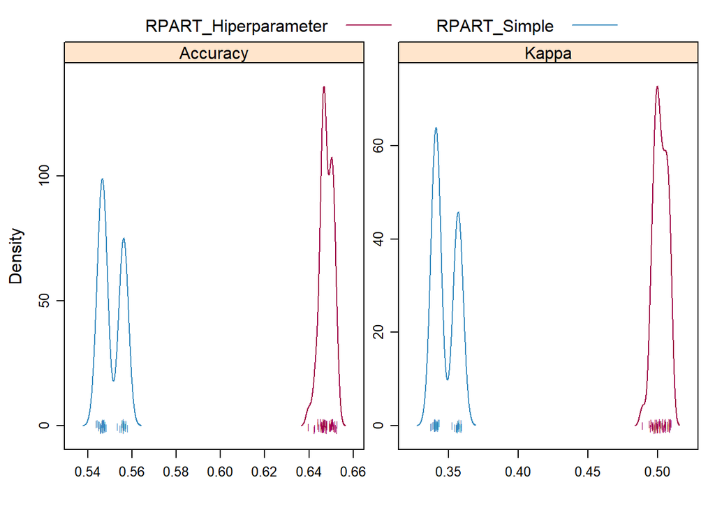

```r
sensory.modelList.rpart<-list(RPART_Simple=modelo.rpart
,RPART_Hiperparameter=modelo.rpart2
)


sensory.resamp.rpart <- resamples(sensory.modelList.rpart)
trellis.par.set(caretTheme())

d1 <- densityplot(sensory.resamp.rpart,
scales =list(x = list(relation = "free"),
y = list(relation = "free")),
auto.key = list(columns = 2),
pch = "|")

print(d1,position=c(0,0,1,1),more=T)
```

```r
confusionMatrix(modelo.rpart)
```

```
## Cross-Validated (5 fold, repeated 10 times) Confusion Matrix
##
## (entries are percentual average cell counts across resamples)
##
##                    Reference
## Prediction          label.BICYCLING label.FIX_running label.FIX_walking
##   label.BICYCLING               0.0               0.0               0.0
##   label.FIX_running             0.0               0.0               0.0
##   label.FIX_walking             0.6               0.1               2.7
##   label.LYING_DOWN              0.4               0.1               0.6
##   label.OR_standing             0.0               0.0               0.0
##   label.SITTING                 0.3               0.1               2.6
##   NS/NC                         0.0               0.0               0.0
##                    Reference
## Prediction          label.LYING_DOWN label.OR_standing label.SITTING NS/NC
##   label.BICYCLING                0.0               0.0           0.0   0.0
##   label.FIX_running              0.0               0.0           0.0   0.0
##   label.FIX_walking              0.1               1.1           1.3   1.5
##   label.LYING_DOWN              21.0               1.8           3.5   5.1
##   label.OR_standing              0.0               0.0           0.0   0.0
##   label.SITTING                  6.5               7.1          31.3  12.1
##   NS/NC                          0.0               0.0           0.0   0.0
##
##  Accuracy (average) : 0.5505
```

```r
confusionMatrix(modelo.rpart2)
```

```
## Cross-Validated (5 fold, repeated 10 times) Confusion Matrix
##
## (entries are percentual average cell counts across resamples)
##
##                    Reference
## Prediction          label.BICYCLING label.FIX_running label.FIX_walking
##   label.BICYCLING               0.4               0.0               0.1
##   label.FIX_running             0.0               0.0               0.0
##   label.FIX_walking             0.3               0.1               2.4
##   label.LYING_DOWN              0.1               0.0               0.2
##   label.OR_standing             0.1               0.0               0.3
##   label.SITTING                 0.5               0.1               2.6
##   NS/NC                         0.1               0.0               0.3
##                    Reference
## Prediction          label.LYING_DOWN label.OR_standing label.SITTING NS/NC
##   label.BICYCLING                0.0               0.1           0.1   0.1
##   label.FIX_running              0.0               0.0           0.0   0.0
##   label.FIX_walking              0.1               0.6           0.7   1.0
##   label.LYING_DOWN              22.9               1.0           1.9   2.5
##   label.OR_standing              0.2               1.2           0.5   0.5
##   label.SITTING                  3.4               6.2          31.2   7.9
##   NS/NC                          1.0               1.0           1.7   6.7
##
##  Accuracy (average) : 0.648
```

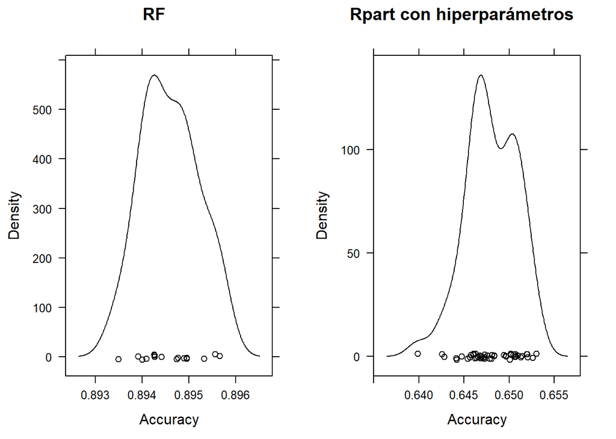

```r
d2 <- densityplot(modelo.rpart2, main = "Rpart con hiperparámetros")
d1 <- densityplot(modelo.rf, main = "RF")
print(d1,position=c(0,0,0.5,1),more=T)
print(d2,position=c(0.5,0,1,1),more=T)
```

```r
confusionMatrix(modelo.rpart2)
```

```
## Cross-Validated (5 fold, repeated 10 times) Confusion Matrix
##
## (entries are percentual average cell counts across resamples)
##
##                    Reference
## Prediction          label.BICYCLING label.FIX_running label.FIX_walking
##   label.BICYCLING               0.4               0.0               0.1
##   label.FIX_running             0.0               0.0               0.0
##   label.FIX_walking             0.3               0.1               2.4
##   label.LYING_DOWN              0.1               0.0               0.2
##   label.OR_standing             0.1               0.0               0.3
##   label.SITTING                 0.5               0.1               2.6
##   NS/NC                         0.1               0.0               0.3
##                    Reference
## Prediction          label.LYING_DOWN label.OR_standing label.SITTING NS/NC
##   label.BICYCLING                0.0               0.1           0.1   0.1
##   label.FIX_running              0.0               0.0           0.0   0.0
##   label.FIX_walking              0.1               0.6           0.7   1.0
##   label.LYING_DOWN              22.9               1.0           1.9   2.5
##   label.OR_standing              0.2               1.2           0.5   0.5
##   label.SITTING                  3.4               6.2          31.2   7.9
##   NS/NC                          1.0               1.0           1.7   6.7
##
##  Accuracy (average) : 0.648
```

```r
confusionMatrix(modelo.rf)
```

```
## Cross-Validated (4 fold, repeated 4 times) Confusion Matrix
##
## (entries are percentual average cell counts across resamples)
##
##                    Reference
## Prediction          label.BICYCLING label.FIX_running label.FIX_walking
##   label.BICYCLING               1.0               0.0               0.0
##   label.FIX_running             0.0               0.2               0.0
##   label.FIX_walking             0.1               0.0               3.9
##   label.LYING_DOWN              0.0               0.0               0.0
##   label.OR_standing             0.1               0.0               0.3
##   label.SITTING                 0.2               0.0               1.4
##   NS/NC                         0.1               0.0               0.2
##                    Reference
## Prediction          label.LYING_DOWN label.OR_standing label.SITTING NS/NC
##   label.BICYCLING                0.0               0.0           0.0   0.0
##   label.FIX_running              0.0               0.0           0.0   0.0
##   label.FIX_walking              0.0               0.4           0.5   0.4
##   label.LYING_DOWN              26.7               0.1           0.1   0.2
##   label.OR_standing              0.1               7.1           0.3   0.2
##   label.SITTING                  0.7               2.1          34.7   2.0
##   NS/NC                          0.1               0.3           0.5  15.9
##
##  Accuracy (average) : 0.8946
```

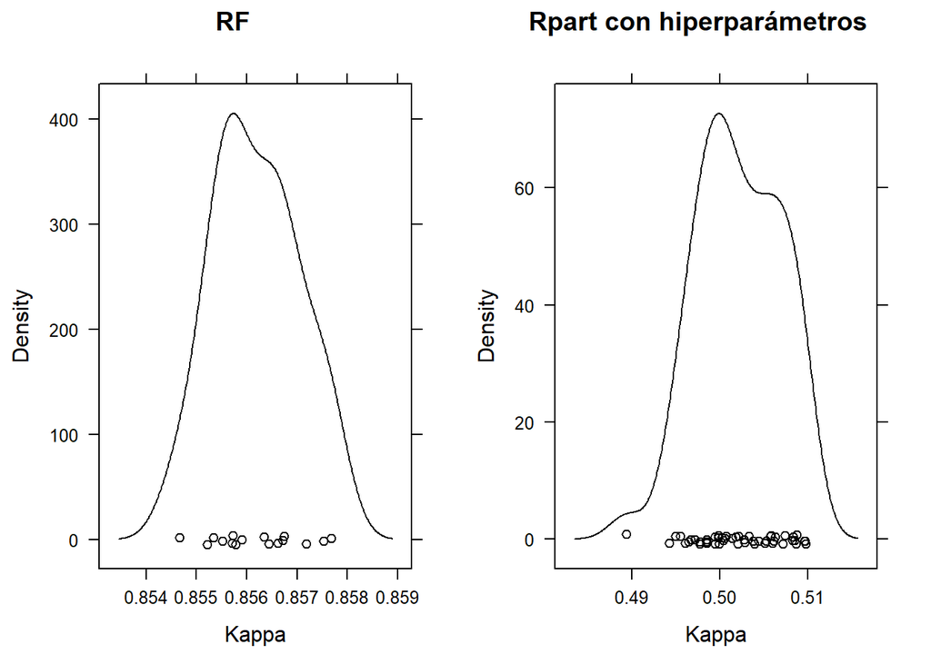

```r
d2 <- densityplot(modelo.rpart2, main = "Rpart con hiperparámetros", metric = "Kappa")
d1 <- densityplot(modelo.rf, main = "RF", metric = "Kappa")
print(d1,position=c(0,0,0.5,1),more=T)
print(d2,position=c(0.5,0,1,1),more=T)
```

We can observe that the model with the adjustment in the hyperparameters of the best results, but still, far from the random forest method that is the one that best compares for this classification problem, but a very high computational cost than the algorithm with the “RF” method has taken 36 hours to execute.

Therefore, we can say that the random forest is the one that best behaves for this classification problem. Even if we modify the rpart hyperparameters, this is not a random forest.

# Neuronal Network

Making use of Keras which is a wrapper, developed in Python, to several low level deep learning frameworks, including TensorFlow. I use keras in its GPU version to have a higher level of processing.

```r
library(processx)
library(devtools)
library(reticulate)
library(keras)
```

To perform the MLP, the data has been reloaded from the beginning, but in this we have taken all the predictors.

```r
labels <- select(data, (c('label.LYING_DOWN', 'label.SITTING', 'label.OR_standing', 'label.FIX_walking', 'label.FIX_running', 'label.BICYCLING')))
datos_entrada <- cbind(tiempo_ciclico, features)
datos_entrada <- cbind(datos_entrada, labels)

vars_entrada <- colnames(select(datos_entrada, -starts_with('label')))
vars_salida <- colnames(select(datos_entrada, starts_with('label')))

#Estimamos los valores para normalizar usando el conjunto de entrenamiento
# Solo usamos las variables que vayamos a preprocesar
preProcMod<-preProcess(datos_entrada[(vars_entrada)],method=c("center","scale"))
# Aplicamos las transformaciones a ambos conjuntos
datos_mlp<-predict(preProcMod,datos_entrada)
```

## First model MLP

We build the model, at the moment we are only going to have a hidden layer. In summary, we have 173 input nodes, 80 in the hidden layer and 6 output nodes corresponding to the main context labels that we want to figure out.

For activation in the input we will use leaky type RelU that allows us negative values (-infinity to + infinity). At the exit we will have a sigmoid type activation since the range for sigmoid is between 0 and 1.

Adam is a combining the advantages of two other extensions of stochastic gradient descent. Specifically: Adaptive Gradient Algorithm (AdaGrad) and Root Mean Square Propagation (RMSProp).

```r
model = keras_model_sequential()
model %>%
layer_dense(units = 80, activation = layer_activation_leaky_relu(), input_shape = (173)) %>%
layer_dense(units = 6, activation = 'sigmoid')
summary(model)

model %>% compile(
loss = 'binary_crossentropy',
optimizer = optimizer_adam(),
metrics = c('accuracy'))
```

```r
set.seed(123)
history = model %>% fit(
as.matrix(datos_mlp[vars_entrada]),
as.matrix(datos_mlp[vars_salida]),
epochs = 20,
batch_size = 128,
validation_split = 0.2,
verbose = 2
)

saveRDS(history, "mlp.rds")
```

We have quite good training and evaluation errors considering that we have only a hidden layer of 80 nodes. Now we plot the training and validation errors throughout the epochs.

```r
history <- readRDS("mlp.rds")

cat("Los errores de entrenamiento y evaluación finales son", history$metrics$loss[20],"y",
history$metrics$val_loss[20],"\n")
```

```
## Los errores de entrenamiento y evaluación finales son 0.133537 y 0.3564022
```

```r
cat("Los valores de accuracy de entrenamiento y evaluación finales son", history$metrics$acc[20],"y",
history$metrics$val_acc[20],"\n")
```

```
## Los valores de accuracy de entrenamiento y evaluación finales son 0.9473315 y 0.8811757
```

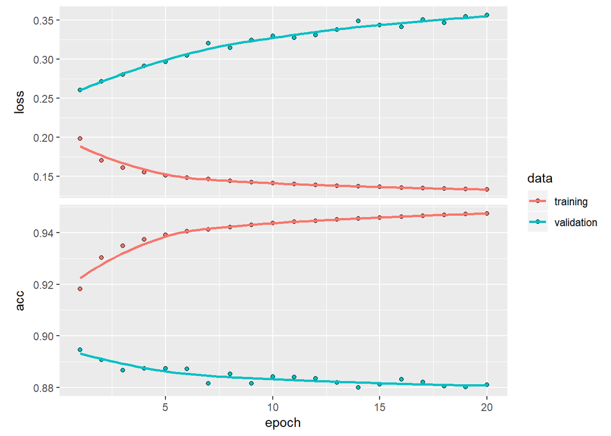

```r
plot(history)
```

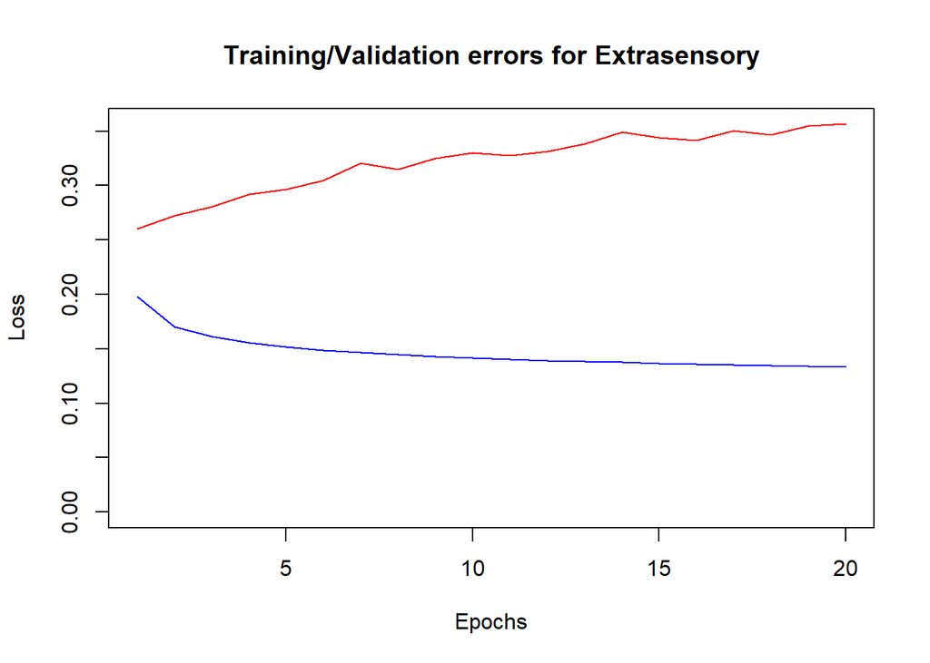

```r
vymax = max(c(history$metrics$loss,history$metrics$val_loss))
plot(history$metrics$loss,main="Training/Validation errors for Extrasensory",col="blue",
     type="l",xlab="Epochs",ylab="Loss",ylim=c(0,vymax))
lines(history$metrics$val_loss,col="red")
```

As we can see, the validation error gets worse after a specific number of epochs. Which means that we have overfitting, We will try to solve it by adding a layer with dropout and we will modify our model adding more complexity. We are going to add two more layers, one dropout and another 200 nodes and again layer dropout. We will increase the epochs and the batch_size.

## Second model MLP

```r
set.seed(123)

model = keras_model_sequential()
model %>%
layer_dense(units = 80, activation = layer_activation_leaky_relu(), input_shape = (173)) %>%
layer_dropout(rate=0.6) %>%
layer_dense(units = 200)  %>%
layer_dropout(rate=0.2) %>%
layer_dense(units = 6, activation = 'sigmoid')
summary(model)

model %>% compile(
loss = 'binary_crossentropy',
optimizer = optimizer_adam(),
metrics = c('accuracy'))


history = model %>% fit(
as.matrix(datos_mlp[vars_entrada]),
as.matrix(datos_mlp[vars_salida]),
epochs = 100,
batch_size = 160,
validation_split = 0.2,
verbose = 2
)

saveRDS(history, "dropout.rds")
```

```r
history <- readRDS("dropout.rds")

cat("Los errores de entrenamiento y evaluación finales son", history$metrics$loss[100],"y",
history$metrics$val_loss[100],"\n")
```

```
## Los errores de entrenamiento y evaluación finales son 0.1958083 y 0.2562161
```

```r
cat("Los valores de accuracy de entrenamiento y evaluación finales son", history$metrics$acc[100],"y",
history$metrics$val_acc[100],"\n")
```

```
## Los valores de accuracy de entrenamiento y evaluación finales son 0.9186381 y 0.8952656
```

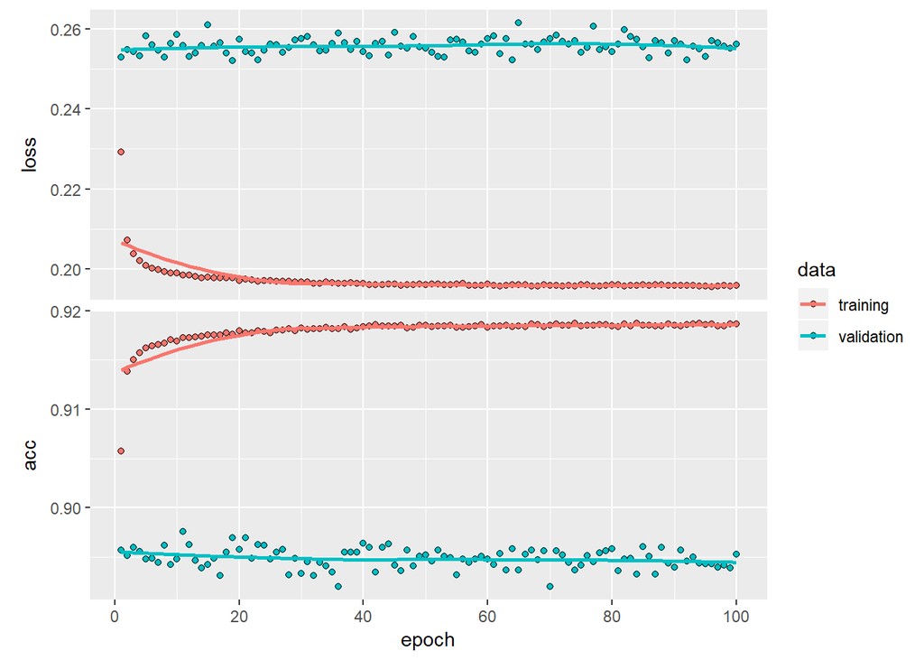

```r
plot(history)
```

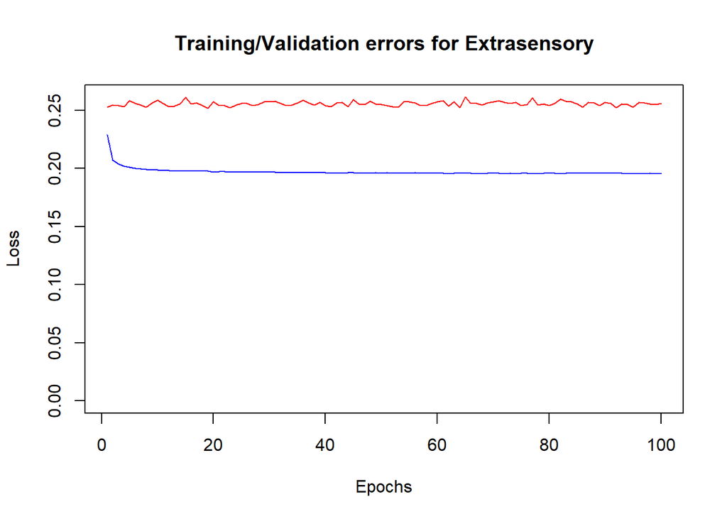

```r
vymax = max(c(history$metrics$loss,history$metrics$val_loss))
plot(history$metrics$loss,main="Training/Validation errors for Extrasensory",col="blue",
     type="l",xlab="Epochs",ylab="Loss",ylim=c(0,vymax))
lines(history$metrics$val_loss,col="red")
```

# Conclusions and future work

I personally prefer the neural networks that have taken much less time to execute than the rf method, probably because I had the possibility to run with the GPU

As a possible extension it would be very interesting to try the elimination of recursive features (rfe) with rfFuncs, and improve the MLP, for example, removing input nodes, that is, keep the rfe predictors and modify the epochs, the number of layers and the number nodes per layer. Another very interesting extension would be to see in real time the model that we have generated for the prediction.